# Predicting MLS Matches using Machine Learning Techniques

Alex Foster, Chris Bajek, Webster An

May 11, 2020

Abstract

Predicting the outcome or different statistics of sports is a massive market for betting and gambling. Additionally, in crisis such as a global pandemic, predicting results can be crucial for determining how the season would have ended. For this project, we will use different machine learning techniques that we learned in Statistical Machine Learning to determine how to predict the outcome of matches in the Major Soccer League. Using data on the MLS season from 2012-2018 we hope to make some predictions regarding the 2019 season

## Introduction

Due to the COVID-19 pandemic in 2020, the majority of sports leagues across the world have halted their seasons. This has lead to varying decisions on how to proceed. Since soccer does not have playoffs, the final standings of the league dictate which teams are promoted or relegated. This can have a massive financial effect on teams in relegation and promotion positions. Some leagues have decided to cancel the rest of the remaining season, while other leagues, like France’s Ligue 1, have decided to end the league as it stands, crowning the current 1st place team. This decision has resulted in several lawsuits.

In the USA, Major League Soccer does not implement promotion or relegation and uses the playoff system like many other American sports leagues. However, due to the chaos in European soccer leagues, we wanted to see if we could create a model that could predict the number of goals each team will score in an MLS match. We intend to do this by examing each team’s overall statistics for each game and team’s season statistics as well. We recognize that this a very difficult task and that soccer, in particular, is one of the hardest sport’s to model not only because of the lack of data but also due to the nature of the sport.

## The Dataset

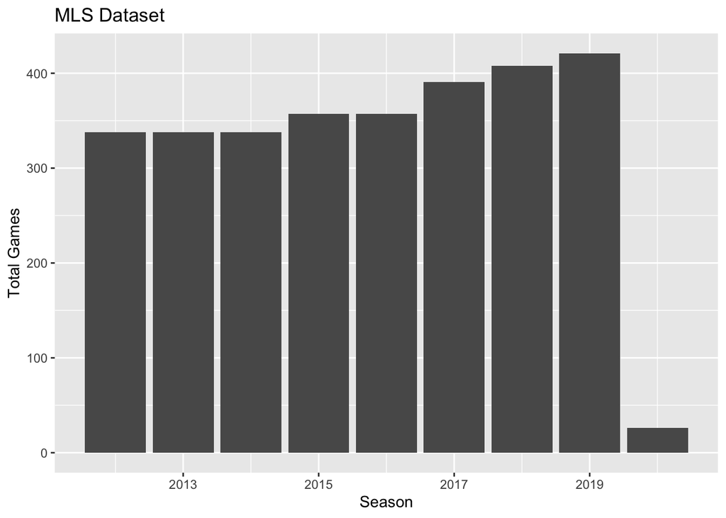

The initial dataset provided us with the outcome and date of each match, teams playing, the number of goals scored by each team and the betting odds. We recognized that we would need more explanatory variables. We created a function that would compute the league table prior to a given date. This allowed us to compute each team’s average goals scored per game, average goals conceded per game for each match, and their position in the league. However, even with our additional explanatory variables, we wrangled our dataset to be better designed for predictive modeling. We split each match into two rows. This meant that each row represented a team with that team’s relevant information. Ultimately, our plan is to have our response variable be Goals. Our dataset had the following structure.

|  | Variable Name | Description |
| --- | --- | --- |
| 3 | Season | Calendar year that a given season occurred (2012 - 2020) |
| 4 | Datetime | Represents the date the match was played on (lubridate datetime object) |
| 5 | Team | Team that we will predict number of goals for. |
| 6 | Opponent | Team’s opponent for given match |
| 7 | Goals | Team’s goals scored in the given match |
| 8 | GoalsAllowed | Opponent goals scored in the given match |
| 9 | Res | Final result of the match (H/A/T) |
| 10 | AGS | Team’s average goals per game prior to this match |
| 11 | OpAGC | Oppoent’s average goals conceded per game prior to this match |
| 12 | Position | Team’s league position prior to this match |
| 13 | OpPosition | Oppoent’s league position prior to this match |
| 14 | TG | Total goals scored in this match |
| 15 | TableDiff | Team’s difference in table position with opponent |
| 15 | GoalDiff | Team’s goal differential prior to this match |
| 15 | GoalScCo | The sum of AGS and OpAGC variables |
| 15 | HA | Dictates whether the Team is home or away for the given match |
| 15 | PH | Betting odds of a home win |
| 15 | PD | Betting odds of a draw |
| 15 | PA | Betting odds of an away win |

### Data Visualizations

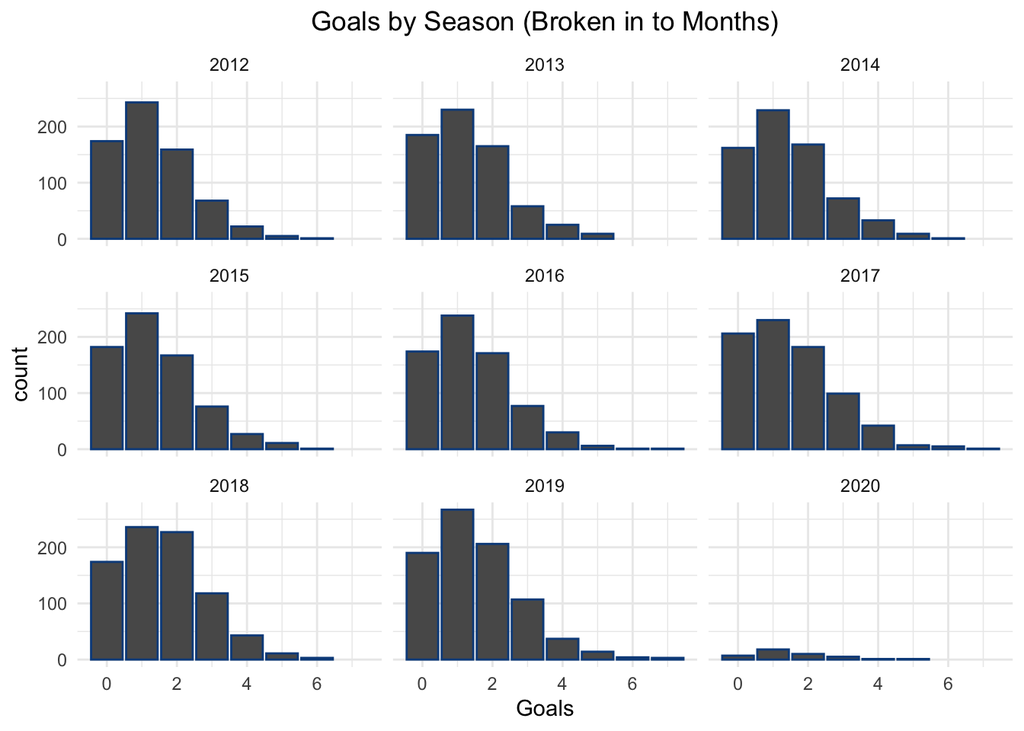

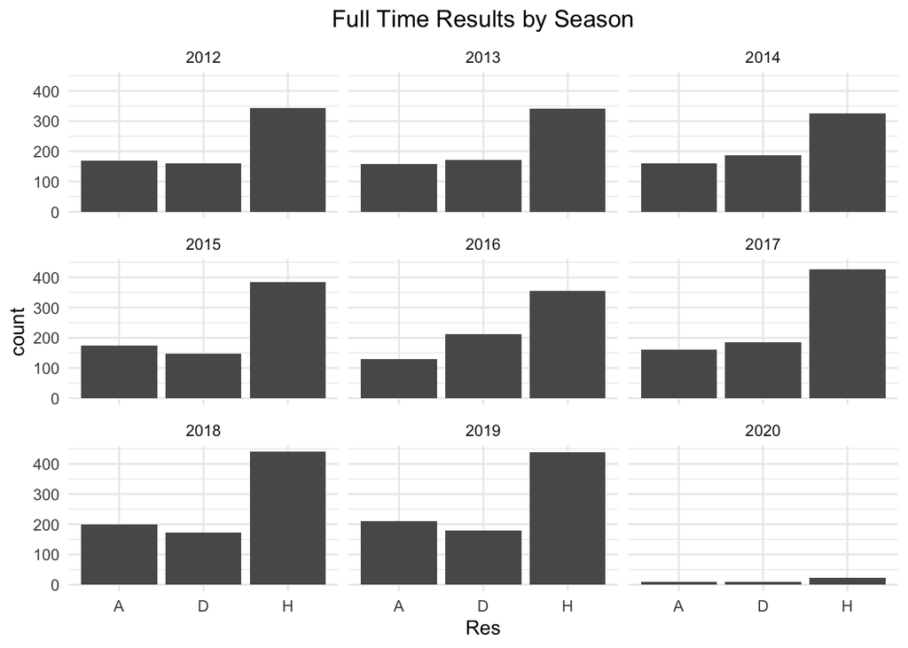

*The graph above depicts full-time results as an Away Win (A), Draw (D), or Home Win (H). As we expect the most common result is a home win, seeming to prove that there is such a thing as home-field advantage.*

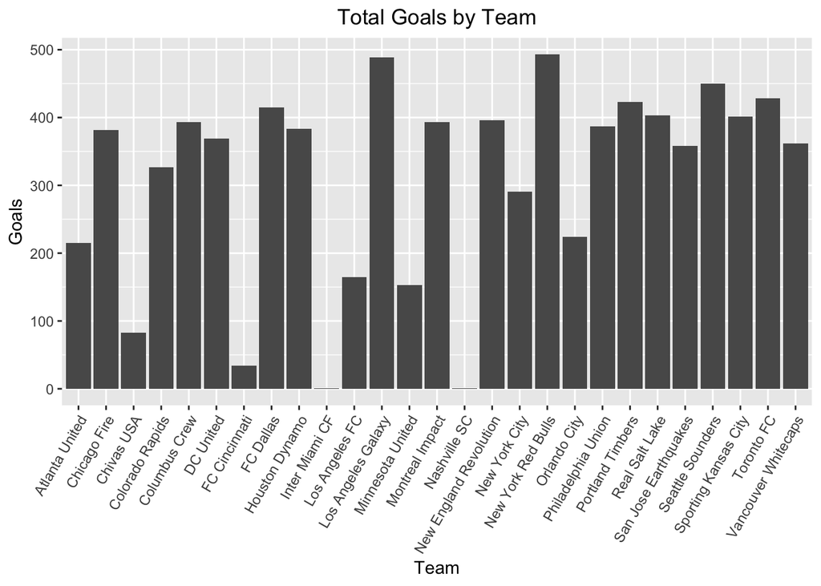

*This plot shows the total number of goals scored by individual teams in MLS. The Total number of goals can be misleading though because some of the teams are much newer than others and haven’t had an opportunity to score goals in all of the seasons in our data.*

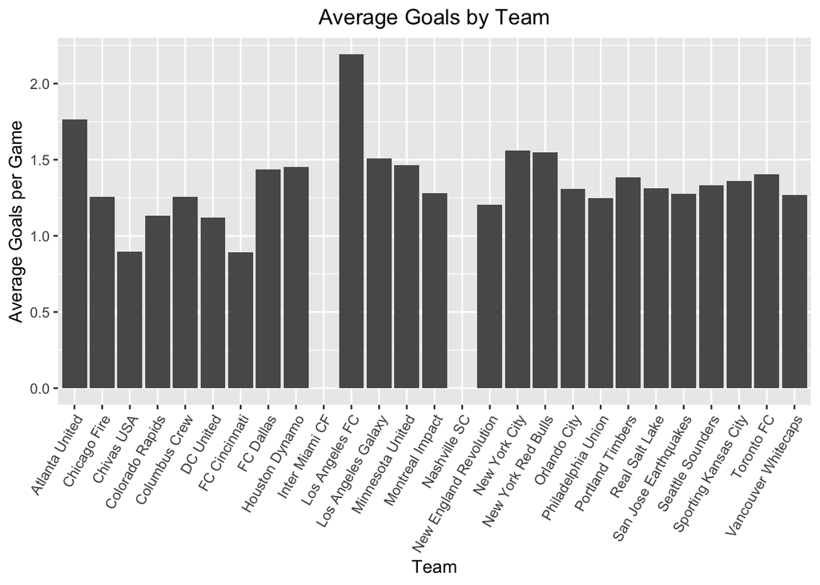

*This plot is similar to the previous one except that it examines the average goals scored per game by each team. The Miami team and the Nashville team were just added to the league so it makes sense that they have little to no goal information.*

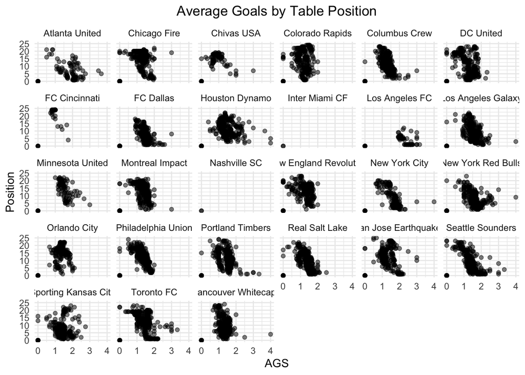

*The plots above show how the average number of goals relates to a team’s position in the MLS table. The lower the position on the y-axis the better a team is doing (being 4th in the table is better than 24th). Generally, it looks like the trend is that a higher number of average goals means a better position in the table.*

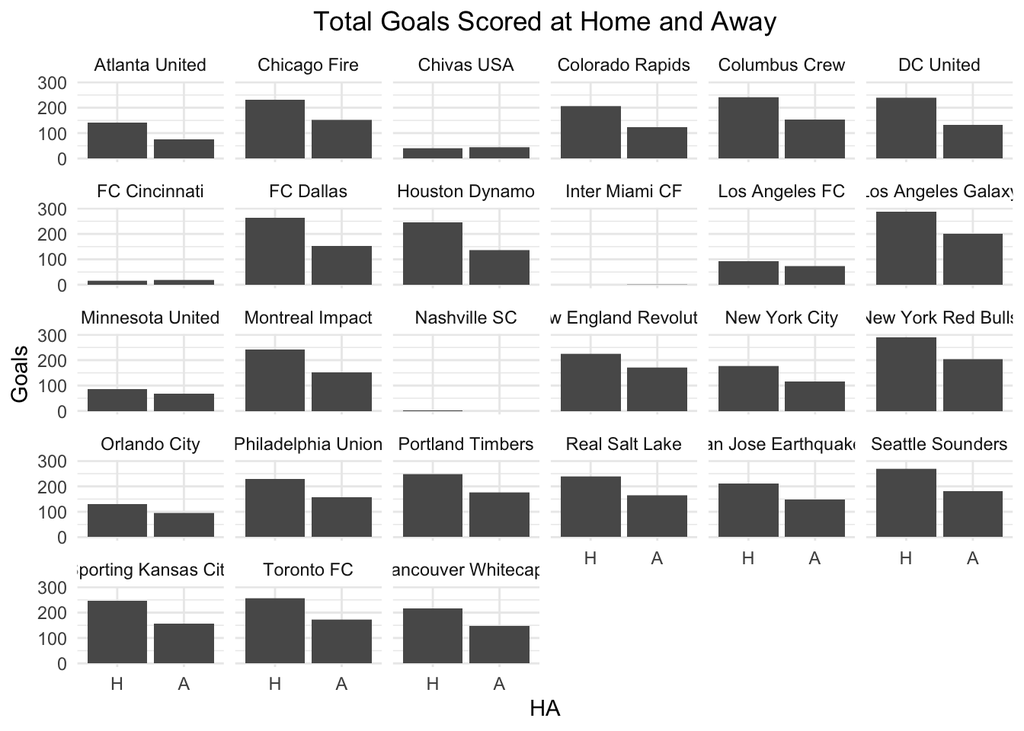

*The plot above shows the number of home and away goals each team has scored over the seasons our data includes. As the results graph show previously, we expect there to be a home-field advantage and this plot shows there is.*

## Modeling: Predict Goals Variable

#### Create training/testing set

```r
df_modeling <- MLS_final
df_train <- df_modeling[which(df_modeling$Season != 2019),]
df_train <- df_modeling[which(df_train$Season != 2020),] # remove 2020 from training set.
df_test <- df_modeling[which(df_modeling$Season == 2019),]
```

Our training set includes all matches from 2012-2018 which is represented by 5006 rows. Our test set contains all matches in the 2019 season and contains 828 rows.

#### Stepwise Selection of Variables

[output not shown]

```
## # A tibble: 61 x 2
##    names                       x
##    <chr>                   <dbl>
##  1 (Intercept)          8.17e-15
##  2 TeamChicago Fire    -3.82e-16
##  3 TeamChivas USA       8.43e-15
##  4 TeamColorado Rapids -2.68e-16
##  5 TeamColumbus Crew   -5.87e-16
##  6 TeamDC United       -1.20e-15
##  7 TeamFC Cincinnati    1.43e-14
##  8 TeamFC Dallas       -7.87e-16
##  9 TeamHouston Dynamo  -1.37e-15
## 10 TeamLos Angeles FC   5.33e-15
## # … with 51 more rows
```

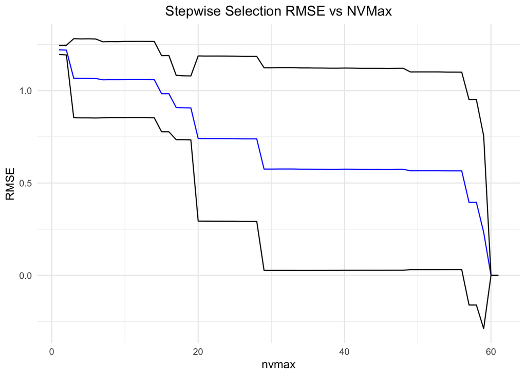

Using the stepwise selection method to examine which variables are most relevant for our model we can see that the best tune is 60 explanatory variables. The coefficients and the variables are shown in the tidy table above. It’s important to note that there are 50 variations of the team and opponent categorical variables because there are 26 teams total. The intercept is the Atlanta United team.

#### OLS

```
## # A tibble: 53 x 5
##    term                  estimate std.error statistic  p.value
##    <chr>                    <dbl>     <dbl>     <dbl>    <dbl>
##  1 (Intercept)              1.94      0.203     9.54  2.18e-21
##  2 `TeamChicago Fire`      -0.641     0.160    -4.00  6.37e- 5
##  3 `TeamChivas USA`        -1.21      0.185    -6.55  6.16e-11
##  4 `TeamColorado Rapids`   -0.839     0.160    -5.23  1.76e- 7
##  5 `TeamColumbus Crew`     -0.619     0.159    -3.88  1.04e- 4
##  6 `TeamDC United`         -0.778     0.159    -4.89  1.04e- 6
##  7 `TeamFC Cincinnati`     -1.18      0.324    -3.64  2.75e- 4
##  8 `TeamFC Dallas`         -0.546     0.160    -3.41  6.44e- 4
##  9 `TeamHouston Dynamo`    -0.704     0.159    -4.42  1.02e- 5
## 10 `TeamLos Angeles FC`     0.224     0.243     0.918 3.59e- 1
## # … with 43 more rows
```

Using the stepwise selection as a guide we have chosen to run an OLS model with Team, Opponent, and GoalsAllowed as the explanatory variables for Goals. Our model summary shows the coefficients and the RMSE is 1.213 when using the training data.

```
##   intercept     RMSE   Rsquared      MAE     RMSESD RsquaredSD      MAESD
## 1      TRUE 1.301197 0.02276852 1.033579 0.03896031 0.02636093 0.03673111
```

When using our OLS model on the testing data we have a CV RMSE of 1.3 which is slightly higher than the training CV RMSE.

#### Lasso Model

```r
set.seed(327)
MLS_lasso_small <- train(
  Goals ~ Team + AGS + Position + OpPosition + HA + TableDiff + OpAGC + GoalScCo,
  data = df_train,
  method = "glmnet",
  tuneGrid = data.frame(alpha = 1, lambda = lambda_grid),
  trControl = trainControl(method = "cv",
                           number = 5,
                           summaryFunction = model_stats,
                           returnResamp = "all",
                           selectionFunction = "oneSE"),
  na.action = na.omit,
  metric = "RMSE",
  maximize = FALSE
)
```

```
##              row column        value
## 1    (Intercept)      1  1.589784283
## 2 TeamChivas USA      1 -0.131051962
## 3            HAA      1 -0.486518749
## 4      TableDiff      1 -0.002109758
## 5       GoalScCo      1  0.029404969
```

We chose to run two lasso models, one normal lasso model, and one tuned to be the smallest model (the model with the largest lambda within one standard error of the best models). Our first model produced an RMSE of 1.174427 and the smaller lasso model had an RMSE of 1.183064. Both of these values are better than the OLS model and higher than the Stepwise-Selection RMSE. We used the testing set on both these and found that we got an RMSE of 1.2379 for both. This is greater than the training set model RMSE than we would like.

#### MARS MLS Model

```r
MLS_mars_best <- train(
  Goals ~ Team + AGS + Position + OpPosition + HA + TableDiff + OpAGC + GoalScCo,
  data = df_train,
  method = "earth",
  trControl = trainControl(method = "cv",
                           number = 5,
                           summaryFunction = model_stats,
                           returnResamp = "all",
                           selectionFunction = "best"),
                           na.action = na.exclude,
  tuneGrid = data.frame(degree = 1, nprune = 2:8)
)
```

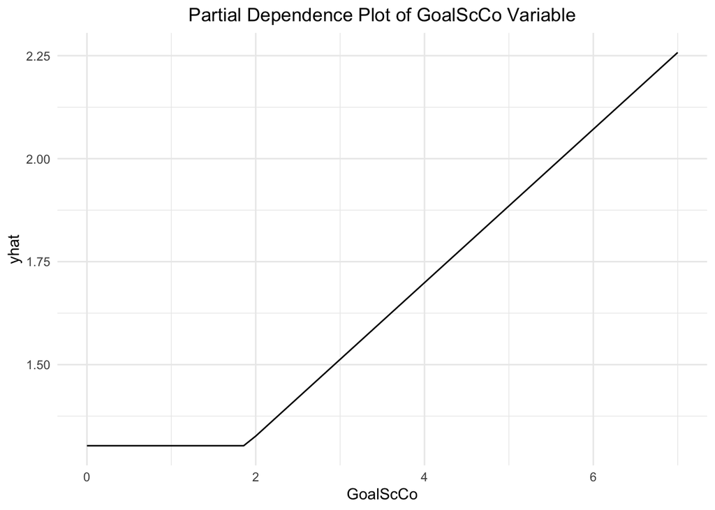

#### KNN Model

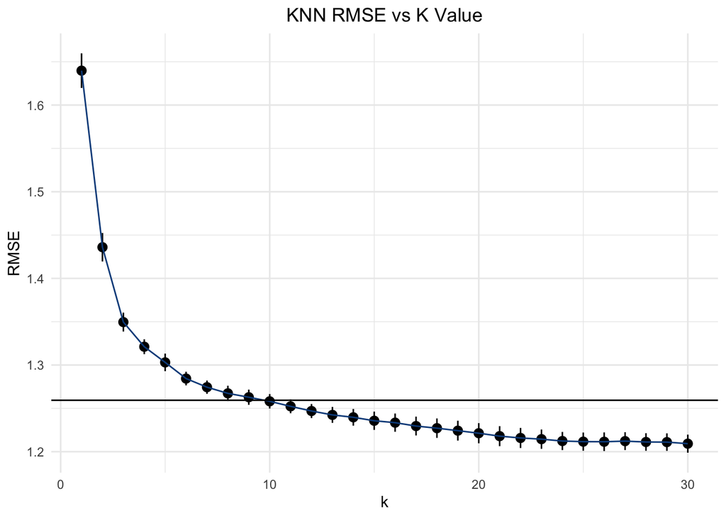

## Conclusion

Overall, we found that it is very difficult to predict the outcome of games. We expected this to be the case. Additionally, we recognized prior to this project that our explanatory variables in our dataset, even after manipulations, were not that strong. Considering all of this we still found a final model. It is the lasso model that we created. Our two lasso models were created using different selection functions. We found that the first one had a lower RMSE value for the training set but that they both had the same RMSE for the testing set. This led us to go with our smaller lasso model because it was a simpler model.

Additionally, we recognize that this model did not perform very well. We have also considered many future steps for this project. We would first like to start by adding more variables. There are several datasets that have ratings for every player and incorporating this would allow our models to not only compare overall team stats but individual player stats as well. Additionally, we would like to use these predictions of total goals scored by each team to compute the full-time result. By doing this we could call our predictions, compute the final result, and then simulate the rest of the season. We could then store our predictions and the final result and use them to rebuild our model for the next week of games. Unfortunately, these future steps were out the scope of time and resources we had for this project.